# Cultural Stereotypes

GMK

June 11, 2023

# Abstract

This study examined stereotypes of Asian American males and females in the 1990s and 2000s. Although stereotypes of Asian Americans are assumed to be abundant and widely held, there is actually a dearth of systematic, empirical research that explores this claim. The existence of these stereotypes is often based on anecdotal evidence such as their widespread use of by the media in portraying and accounting for the behavior of Asian Americans. In light of these concerns, the authors assessed cultural stereotypes of Asian American males and females with two large samples in the 1990s and 2000s. Using an updated version of the adjective list employed in the classic Princeton studies of stereotyping (Gilbert, 1951; Karlins, Coffman, & Walters, 1969; Katz & Braly, 1933) modified for use with Asian American targets, participants were asked to check those adjectives that they knew to be part of the cultural stereotype of Asian American males and females. This paper presents findings regarding (1) the degree to which these respondents employed a consistent stereotypic profile of Asian Americans, (2) differences and similarities in the profile for Asian American males and females, and (3) differences and similarities in the profile for Asian American males and females in the 1990s and 2000s, and (4) differences and similarities in stereotypes held by male versus female respondents, members of different ethnic groups, and those with different social class affiliations. Results are also discussed in light of controversies surrounding the notion of Asian Americans as the “model minority.”

# Consistency in and Pervasiveness of Asian American Stereotypes

Consistency in and Pervasiveness of Asian American Stereotypes In 2011, Amy Chua released the “Battle Hymn of the Tiger Mother,” a book about the parenting style and the childrearing practices she employed to raise her own two kids. Although presented in a mildly self-deprecating manner, she received much criticism about her austere parenting style, both from the mainstream and the Asian American community. In 2012, the National Basketball Association witnessed the emergence of its first Asian American player, Jeremy Lin, a 23 year-old Harvard graduate who initially went undrafted but became wildly popular in New York and elsewhere. In less than a span of 25 games, Lin captivated the fans of New York and the NBA and the imaginations of Asians in the U.S. and the global context. Surprised experts provided commentary on the sudden rise of the first Asian American male NBA player in an arena dominated by African Americans and White Americans.  
In both cases, the media and the public relied on Asian American stereotypes to understand the experiences of Chua and Lin and, at the same time, and flamed the stereotypes of Asian American men and women to negatively characterize their experiences and success. On the one hand, reporters and experts used stereotypes to define and describe Amy Chua and Jeremy Lin. On the other hand, readers and fans relied on these stereotypes to make sense of and explain their experiences. Although these cases represent two individuals, on a larger scale they illustrate the ways in which people and institutions may stereotype a smaller community of people and the challenges these stereotypes may place on those who are targeted. For Asian Americans, they represent some of the challenges they face for a population that constitutes only 4.8% of the total U.S. population but whose success has been highly fragmented in various domains. Since 1990, Asian Americans have increased by 101%, with an increase of nearly 41% and 43% each decade. Their representation of the total U.S. population has increased from 2.9% in 1990 to 3.6% in 2000 to 4.8% in 2010 (note: conservative estimates using race alone because of 1990 data). In 2010, people of Asian descent had the second highest labor force participation at 64.7%, behind White Americans at 65.1% (2010). Among people age 25 and older participating in the labor force, 57% of Asian Americans had a bachelor’s degree or higher. In contrast, 35% of White Americans had a bachelor’s degree or higher. Asian Americans and White Americans were more likely to work in management, professional, and related occupations than other ethnic groups. Nearly half of Asian American men (48%) and women (46%) worked in these occupations, whereas 35% of White American men and 42% of women worked in the same occupations. Although Asian Americans accounted for 5% of the all workers in the United States, they represented a substantial percentage of “personal appearance workers” (51%), medical scientists and computer software engineers (28%), and physicians and surgeons (6%). In spite of this attention to Asian Americans success, there is actually a dearth of systematic, empirical research that explores this claim. Even in those few cases where empirical evidence of the stereotyping of Asian Americans (Bannai & Cohen, 1985; Niemann, Jennings, Rozelle, Baxter, & Sullivan, 1994; Toupin & Son, 1991; Wong, Owen, Tran, Collins, & Higgins, 2012; Yee, 1992) and their impact on those who are targeted (Shen, Wang, & Swanson, 2011; Son & Shelton, 2011) have been presented, little effort has been made to determine how consistent these ideas are with regard to Asian American males versus females, or how widely held they are across different groups in the population, e.g., gender or ethnic. This paper examines the cultural stereotypes of Asian American men and women in the 1990s and 2000s.

# Research on Asian American Stereotypes

A review of Asian American stereotypes represented largely by the popular press over the past forty years leads one to believe that, for the most part, descriptions of Asian Americans have changed from negative to positive since the mid-19th Century when Chinese workers first started to appear as gold miners and railroad workers in California. At that time, they were described as “alien, insidious, and inscrutable,” an image that was largely disseminated by businessmen, politicians, and missionaries who had contact with them (Takaki, 1989; Yee, 1992). The image of Asians Americans began to change in the late 1960s when they were described as persistent, hard working immigrants who achieved the “American dream.” According to some (Lee, 1996; Takaki, 1989), this perception was partly a result of the mounting struggle between White and Black America and the need for a “successful” minority group with which to discipline African Americans. This image of Asian Americans was crystallized in the mid-80’s when politicians and scholars lauded Asian Americans for their “success” in American society. These portrayals emphasized strong family values, business savvy, and academic achievement, which have subsequently become the core of a model minority image of Asian Americans and has been used to explain their success and to motivate others…. Studies examining Asian American stereotypes generally portray a positive image of Asian Americans. This positive view of Asian Americans can, however, invoke both positive and negative emotions such as feelings of admiration for those who believe that Asian Americans are intelligent and obedient but also feelings of hostility and resentment (Ho & Jackson, 2001). However, recent studies have shown some diversity in stereotype content of Asian Americans as being competent but warm (Cuddy, Fiske, & Glick, 2007; Fiske, Cuddy, Glick, & Xu, 2002). These findings show that Asian Americans are envied groups similar to Jews where they are respected because of their perceived competence but disliked because of their perceived lack of warmth. More recently, Wong et al. (2012) investigated gender differences in Asian American stereotypes using open-ended responses and found specific stereotypes in reference to Asian American males. These included: a) interpersonal deficits, b) intelligence, c) intense diligence, d) unflattering physical attributes, e) physical ability distortions, f) perpetual foreigner, and g) sexual/romantic inadequacies. Using cluster analysis, these seven categories of stereotypes were then grouped into three clusters: “Body-Mind Stereotypes,” “Nerd Stereotypes,” and “Outsider Stereotypes.”

Stereotype Content Model While the body of literature in examining the implications of Asian American stereotypes on those who are targeted is limited, some recent studies have demonstrated the relationship between stereotypes and psychological outcomes. For example, in addition to identifying three clusters of Asian American male stereotypes, Wong et al. (2012) found that those Asian American participants who were more likely to report “Outsider Stereotypes” also reported higher levels of depressive symptoms relative to those who were more likely to report the other two clusters. Those who were grouped in the “Nerd Stereotypes” were more likely to report lower levels of the interdependent self-construal. While these findings demonstrate a relationship between stereotypes and psychological outcomes, they do not necessarily show that these participants have internalized the Asian American stereotypes. One study examined the extent to which Asian Americans internalize their racial stereotypes by developing the Internalization of Asian American Stereotypes Scale (IAASS; Shen, Wang, & Swanson, 2011). Findings from exploratory and confirmatory factor analyses showed a four-factor structure: a) “Difficulties with English Language Communication,” “Pursuit of Prestigious Careers,” “Emotional Reservation,” and “Expected Academic Success.” A study using a daily diary method showed that Asian American students with higher levels of stigma consciousness reported greater concerns about appearing intelligent in front of their European American roommates (Son & Shelton, 2011). They also reported greater anxiety and contact avoidance as well as greater perceived needs to adjust to their roommates. Interestingly, for Asian Americans with European American roommates, the relationships between stigma consciousness and greater anxiety and perceived need to adjust to their roommates were mediated by their concerns about appearing intelligent. Priming participants with Asian American stereotypes has been used to demonstrate the extent to which stereotypes can affect performance for Asian Americans and non-Asian Americans (Shih, Pittinsky, & Ambady, 1999).

# The Present Study

The present study focuses on the cultural stereotypes of Asian American males and females among undergraduate students using an updated version of an adjective checklist procedure. This study aims to address the following: 1) the degree to which these respondents employ a consistent stereotypic profile of Asian Americans; 2) differences and similarities in the profile for Asian American males and females; 3) differences and similarities in the profile for Asian American males and females, and 4) differences and similarities in stereotypes held by male vs. female respondents, members of different ethnic groups (e.g., European American, Asian American, and African American/Hispanic/Biracial), and those with different social class backgrounds.

# Method

Participants  
The original sample of respondents included 151 Boston College undergraduate students from introductory and research methods psychology courses participating in a mass testing session in exchange for research participation credit. 11 respondents were dropped because of missing demographic information, reducing the total number of respondents to 140. Of these respondents, 92 were female and 48 were male, with a mean age of 19. The distribution of ethnicity among the respondents was the following: White, 73.6 percent; Asian American, 8 percent; Hispanic American, 5.7 percent; African American, 4.3 percent; Biracial, 5 percent; other (i.e., foreign exchange student), 3.6 percent.

# Results

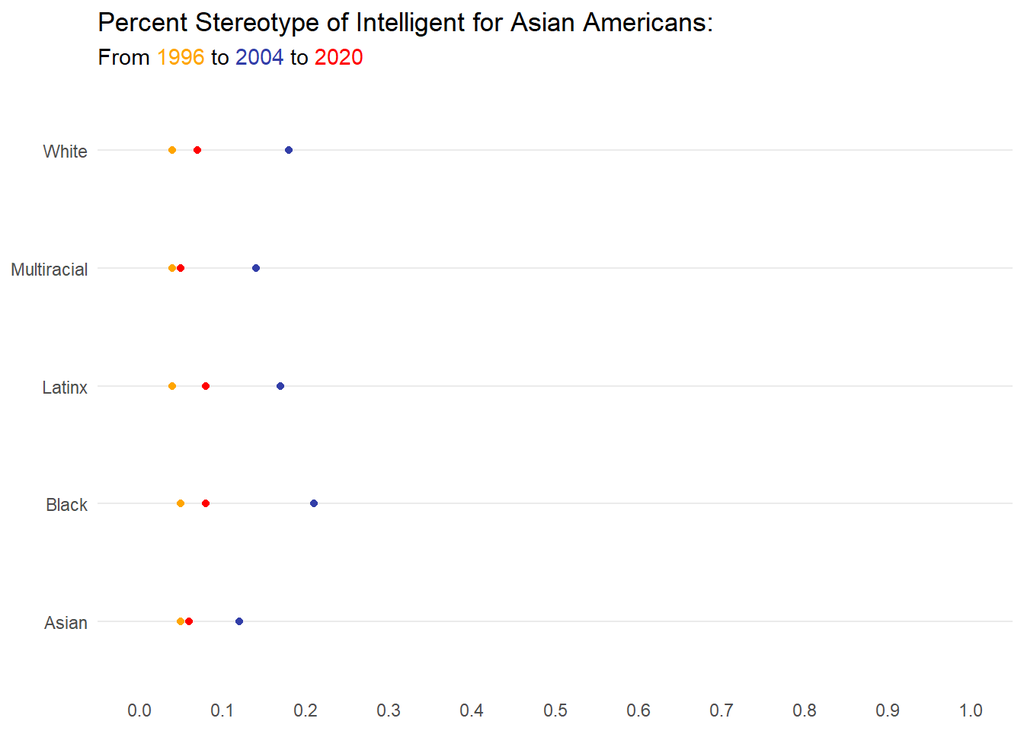

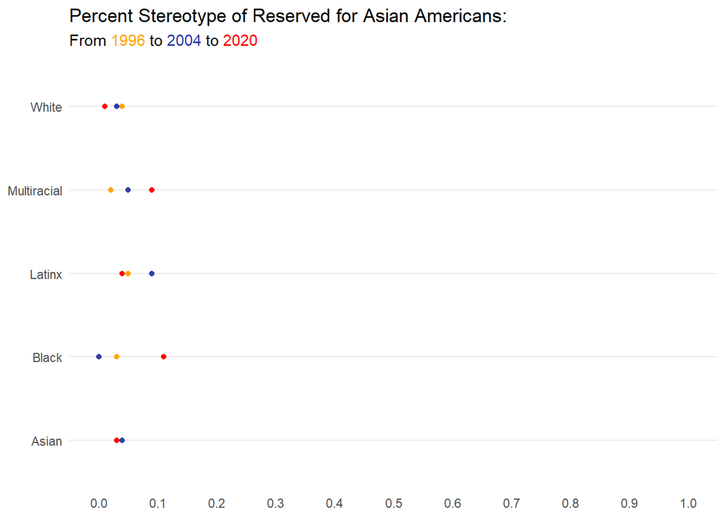

# Discussion

# Future Research

In the stereotype literature, most studies focus on the formation of stereotypes but generally fail to address how people react to stereotypes. One exception is Claude Steele and his colleagues (1995, 1997) who have examined how negative societal stereotypes affect the academic performance of women and African Americans in academic testing situations. Their findings demonstrate powerfully the effects of negative societal stereotypes on the test performance of those who are their targets. But what are the consequences of a societal stereotype that has the superficial appearance of being positive? Some researchers have questioned the accuracy of the model minority stereotype in representing Asian Americans (Lee, 1996; Takaki, 1989; Toupin & Son, 1991). They argue that the model minority stereotype is a myth that fails to account for considerable variability and diversity in the Asian American community. In effect, Asian Americans are seen as permanent immigrants with a monolithic culture that leads them to adapt to white middle class standards to “succeed” (Lee, 1996). In a study that examined the model minority stereotype, Toupin and Son (1991) demonstrated that all Asian Americans are not aware of the model minority stereotype, and, yet, may be vulnerable to fulfilling the expectations that accompany it, often at the cost of their developmental and psychological well-being. Furthermore, being cast as the model minority pits Asian Americans against other minority groups no doubt with important personal and interpersonal consequences for all parties. Future research needs to focus more on these kinds of outcomes bearing in mind that stereotypes about Asian Americans have roots in the larger context of the politics of multiracial society.